# Lab 9

## Question 2

This is Exercise 10 in Chapter 9 of the Textbook [R].

### Question 2(a)

Using R and the [Hypothetical UK Housing Prices dataset](http://spatial.binghamton.edu/geog533/data/UK_Housing.csv), construct a regression equation using housing price as the dependent variable, and bedrooms, bathrooms, date built, garage, fireplace, floor area, and whether the home is detached as the independent variables. Investigate the importance of multicollinearity and outliers. Comment on the weaknesses of this specification, and on the results.

```r
url = "http://spatial.binghamton.edu/geog533/data/UK_Housing.csv"
UK_Housing <- read.csv(url)

price <- UK_Housing$price
garage <- UK_Housing$garage
bedrooms <- UK_Housing$bedrooms
bathrooms <- UK_Housing$bathrooms
date_built <- UK_Housing$datebuilt
floor_area <- UK_Housing$floorarea
detached <- UK_Housing$detached
fireplace <- UK_Housing$fireplace
m <- lm(price ~ garage + bedrooms + bathrooms + date_built + floor_area + detached + fireplace)
summary(m)
```

```
##
## Call:
## lm(formula = price ~ garage + bedrooms + bathrooms + date_built +
##     floor_area + detached + fireplace)
##
## Residuals:
##    Min     1Q Median     3Q    Max
## -38150  -6933  -1086   6705  64014
##
## Coefficients:
##               Estimate Std. Error t value Pr(>|t|)
## (Intercept) -256087.18   34854.98  -7.347 8.50e-13 ***
## garage        10980.77    1274.94   8.613  < 2e-16 ***
## bedrooms        686.01     742.27   0.924   0.3558
## bathrooms      2637.29    1526.36   1.728   0.0846 .
## date_built      130.36      17.84   7.306 1.12e-12 ***
## floor_area      374.18      22.22  16.842  < 2e-16 ***
## detached      13186.76    2346.12   5.621 3.19e-08 ***
## fireplace     -3144.39    1227.89  -2.561   0.0107 *
## ---
## Signif. codes:  0 '***' 0.001 '**' 0.01 '*' 0.05 '.' 0.1 ' ' 1
##
## Residual standard error: 11550 on 491 degrees of freedom
## Multiple R-squared:  0.6967, Adjusted R-squared:  0.6924
## F-statistic: 161.1 on 7 and 491 DF,  p-value: < 2.2e-16
```

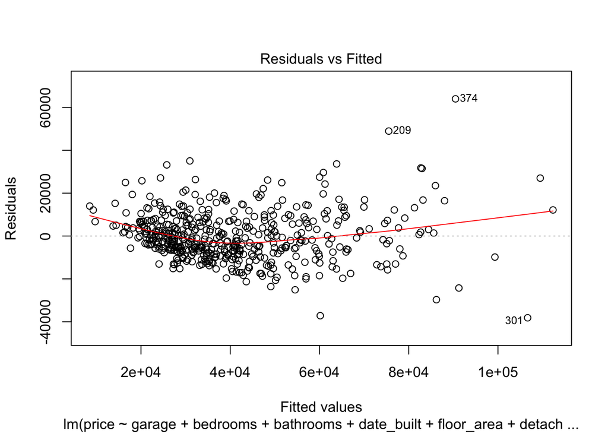

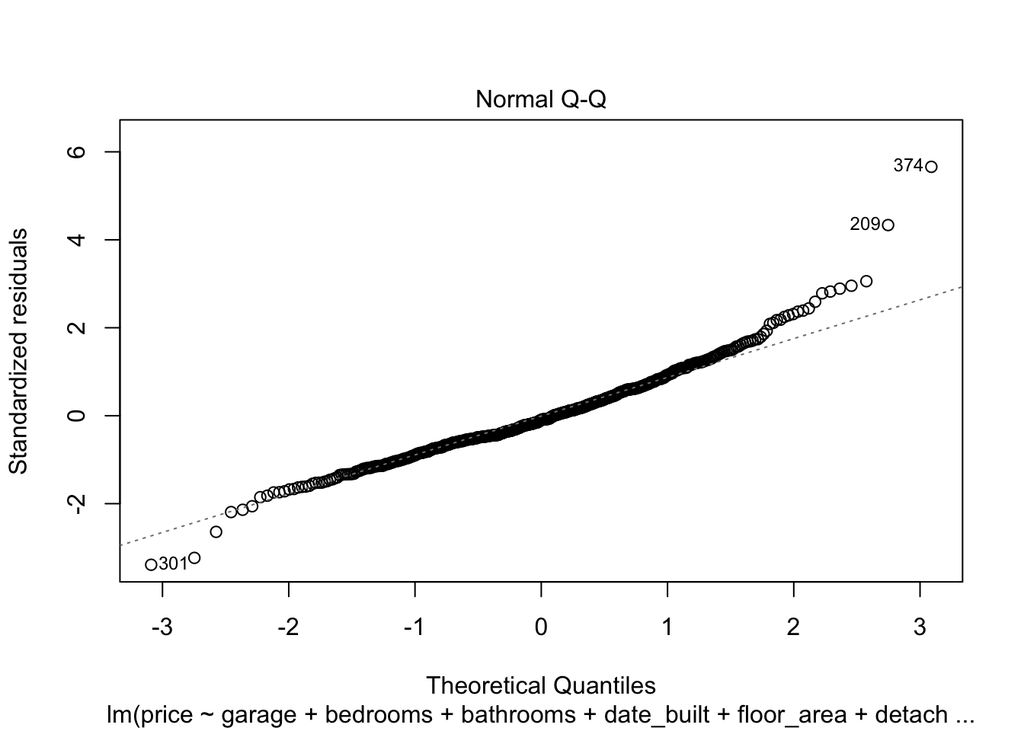

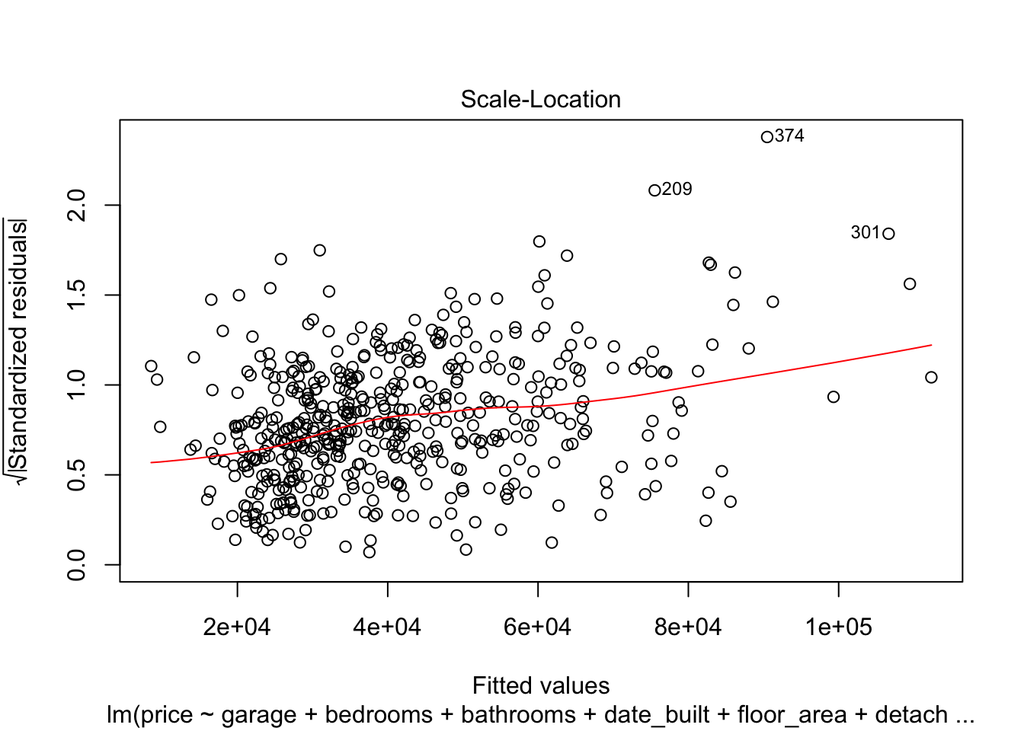

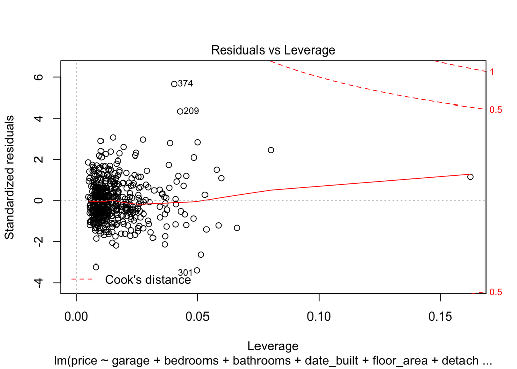

```r
plot(m)
```

```r
print('There appears to be an outlier coefficient that varies from the norm on the regression line at the upper end of the line.')
```

```
## [1] "There appears to be an outlier coefficient that varies from the norm on the regression line at the upper end of the line."
```

### Question 2(b)

Attempt to improve the regression equation found in (a). Justify your decisions in constructing and carrying out the analysis.

```r
improved_regression <- step(m, direction = "backward")
```

```
## Start:  AIC=9343.39
## price ~ garage + bedrooms + bathrooms + date_built + floor_area +
##     detached + fireplace
##
##              Df  Sum of Sq        RSS    AIC
## - bedrooms    1 1.1388e+08 6.5578e+10 9342.3
## <none>                     6.5464e+10 9343.4
## - bathrooms   1 3.9804e+08 6.5862e+10 9344.4
## - fireplace   1 8.7433e+08 6.6339e+10 9348.0
## - detached    1 4.2121e+09 6.9676e+10 9372.5
## - date_built  1 7.1168e+09 7.2581e+10 9392.9
## - garage      1 9.8904e+09 7.5355e+10 9411.6
## - floor_area  1 3.7819e+10 1.0328e+11 9568.9
##
## Step:  AIC=9342.26
## price ~ garage + bathrooms + date_built + floor_area + detached +
##     fireplace
##
##              Df  Sum of Sq        RSS    AIC
## <none>                     6.5578e+10 9342.3
## - bathrooms   1 3.8265e+08 6.5961e+10 9343.2
## - fireplace   1 8.6500e+08 6.6443e+10 9346.8
## - detached    1 4.3063e+09 6.9884e+10 9372.0
## - date_built  1 7.7124e+09 7.3290e+10 9395.7
## - garage      1 1.0025e+10 7.5603e+10 9411.2
## - floor_area  1 6.0089e+10 1.2567e+11 9664.8
```

```r
summary(improved_regression)
```

```
##
## Call:
## lm(formula = price ~ garage + bathrooms + date_built + floor_area +
##     detached + fireplace)
##
## Residuals:
##    Min     1Q Median     3Q    Max
## -37770  -7023  -1169   6448  63341
##
## Coefficients:
##               Estimate Std. Error t value Pr(>|t|)
## (Intercept) -261361.96   34379.42  -7.602 1.49e-13 ***
## garage        11040.84    1273.09   8.672  < 2e-16 ***
## bathrooms      2583.96    1525.04   1.694   0.0908 .
## date_built      133.39      17.54   7.607 1.44e-13 ***
## floor_area      385.98      18.18  21.233  < 2e-16 ***
## detached      13311.35    2341.90   5.684 2.26e-08 ***
## fireplace     -3127.21    1227.57  -2.547   0.0112 *
## ---
## Signif. codes:  0 '***' 0.001 '**' 0.01 '*' 0.05 '.' 0.1 ' ' 1
##
## Residual standard error: 11550 on 492 degrees of freedom
## Multiple R-squared:  0.6962, Adjusted R-squared:  0.6925
## F-statistic: 187.9 on 6 and 492 DF,  p-value: < 2.2e-16
```

```r
print('I used the backward stepwise regression because it will remove the underperforming independent variables, if there are any. The improved model excluded the bedrooms independent variable.')
```

```
## [1] "I used the backward stepwise regression because it will remove the underperforming independent variables, if there are any. The improved model excluded the bedrooms independent variable."
```